# O pakiecie

## O pakiecie

Pakiet `SuperFarmerKapibary` symuluje jednoosobową rozgrywkę w grę SuperFarmera według powszechnie funkcjonujących zasad (bez modyfikacji ani parametryzacji reguł gry). Pozwala na przeprowadzenie pojedynczej gry z zastosowaniem przygotowanej strategii oraz zbadania jej efektywności poprzez analizę wyników symulacji składającej się z dowolnie określonej liczby powtórzeń gry. Pakiet pozwala również na zwizualizowanie wyników gry na histogramie oraz analizę prostych statystyk opisujących rozkład wyników gry.

## Strategie

W pakiecie zdefiniowano dwie strategie. Pierwsza strategia polegała na możliwie szybkiej zamianie niżej premiowanych zwierząt na wyżej premiowane zwierzęta (premia liczona w ewiwalencie liczby królików). Strategia druga powstała jako korekta strategii pierwszej tak, aby nie zapominać o wymianach wyżej premiowanych zwierząt na niższe, gdy posiadamy zbyt dużo niepotrzebnych, wartościowych zwierząt a zbyt mało zwierząt o niższej wartości.

#### Parametry:

- stanGracza - nazwany wektor długości 7 opisujący stan stada gracza

#### Wynik:

- stanGracza - nowy, zaktualizowany o reguły ze strategii, nazwany wektor długości 7 opisujący stan stada gracza

## strategia_Pierwsza

### Przykłady:

```r
library(SuperFarmerKapibary)
stanGry <- c(5,5,5,0,0,0,0)
print(stanGry)
```

```
## [1] 5 5 5 0 0 0 0
```

```r
stanGry <- strategia_Pierwsza(stanGry)
print(stanGry)
```

```
##    krolik      owca    swinia     krowa       kon maly_pies duzy_pies
##         5         5         2         1         0         0         0
```

```r
stanGry <- strategia_Pierwsza(stanGry)
print(stanGry)
```

```
##    krolik      owca    swinia     krowa       kon maly_pies duzy_pies
##         5         3         3         1         0         0         0
```

```r
stanGry <- strategia_Pierwsza(stanGry)
print(stanGry)
```

```
##    krolik      owca    swinia     krowa       kon maly_pies duzy_pies
##         5         1         4         1         0         0         0
```

## strategia_Druga

#### Przykłady:

```r
library(SuperFarmerKapibary)
stanGry <- c(5,5,5,0,0,0,0)
print(stanGry)
```

```
## [1] 5 5 5 0 0 0 0
```

```r
stanGry <- strategia_Druga(stanGry)
print(stanGry)
```

```
##    krolik      owca    swinia     krowa       kon maly_pies duzy_pies
##         5         5         2         0         0         0         1
```

```r
stanGry <- strategia_Druga(stanGry)
print(stanGry)
```

```
##    krolik      owca    swinia     krowa       kon maly_pies duzy_pies
##         5         3         3         0         0         0         1
```

```r
stanGry <- strategia_Druga(stanGry)
print(stanGry)
```

```
##    krolik      owca    swinia     krowa       kon maly_pies duzy_pies
##         5         1         4         0         0         0         1
```

## Główne funkcje użyte w pakiecie

## gra

Niniejsza funkcja ma na celu przeprowadzenie pełnej gry SuperFarmer dla jednego gracza, który posługuje się strategią zdefiniowaną jako argument funkcji.

#### Parametry:

- strategia - Funkcja opisująca zbiór reguł, które reagują na aktualny stan stada gracza i zwraca nowy stan stada po wykonaniu wszystkich wymian zgodnie z zasadami gdy

#### Wynik:

Funkcja zwraca liczbę tur, jaka była niezbędna do zakończenia gdy przy zastosowanej strategii

#### Przykłady:

```r
SuperFarmerKapibary::gra(strategia=SuperFarmerKapibary::strategia_Pierwsza)
```

```
## [1] 19
```

```r
SuperFarmerKapibary::gra(strategia=SuperFarmerKapibary::strategia_Druga)
```

```
## [1] 37
```

## badaj_gre

#### Parametry:

- strategia - Strategia, którą będziemy testować.
- powt - Liczba badanych gier.
- progressBar - Gdy TRUE wyświetlany jest tekstowy pasek postępu, gdy FALSE paska nie ma. Domyślnie FALSE.
- histogram - Gdy TRUE wyświetlany jest histogram wyników, gdy FALSE histogramu nie ma. Domyślnie FALSE.
- statystyki - Gdy TRUE wyświetlane są statystyki rozkłądu wyników, gdy FALSE to nie. Domyślnie TRUE.
- zwrocRozklad - Gdy TRUE funkcja zwraca nazwany wektor statystyk opisowych. Domyślnie FALSE.

#### Przykłady:

Wywołanie z domyślnymi wartościami parametrów:

```r
SuperFarmerKapibary::badaj_gre(strategia = SuperFarmerKapibary::strategia_Pierwsza,
                               powt      = 100)
```

```
##    Min. 1st Qu.  Median    Mean 3rd Qu.    Max.
##   14.00   36.75   70.00   84.68  121.20  347.00
```

Wywołanie z parametrem histogram=TRUE:

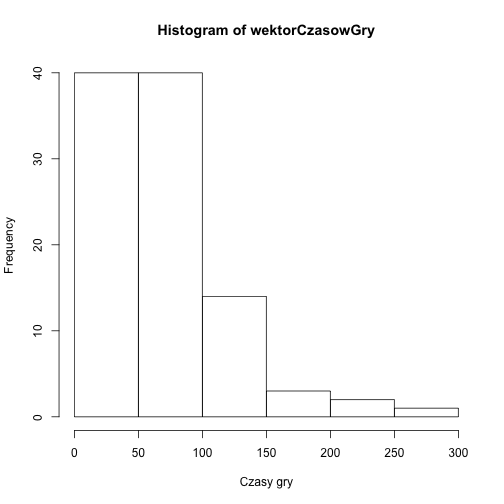

```r
SuperFarmerKapibary::badaj_gre(strategia    = SuperFarmerKapibary::strategia_Druga,
                               powt         = 100,
                               progressBar  = FALSE,
                               statystyki   = FALSE,
                               histogram    = TRUE)
```

Wywołanie z parametrem zwrocRozklad=TRUE:

```r
rozklad <- SuperFarmerKapibary::badaj_gre(strategia    = SuperFarmerKapibary::strategia_Druga,
                                          powt         = 100,
                                          progressBar  = FALSE,
                                          statystyki   = FALSE,
                                          zwrocRozklad = TRUE)
```

# Testy innych pakietów

### SuperFarmer.SuperDziewczyn

```
##    Min. 1st Qu.  Median    Mean 3rd Qu.    Max.
##   12.00   33.25   48.50   59.95   79.00  181.00
```

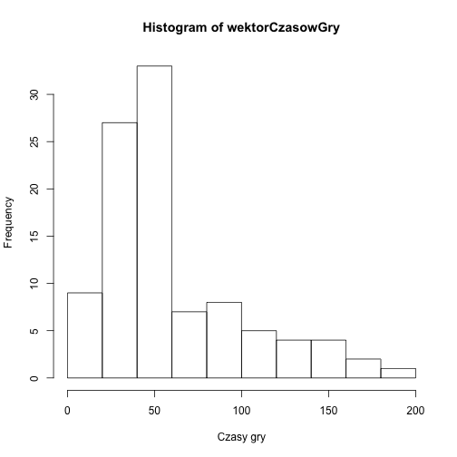

```r
SuperFarmerKapibary::badaj_gre(SuperFarmer.SuperDziewczyn::strategia_owce,
                               powt=100,
                               progressBar=FALSE,
                               histogram=TRUE)
```

```
##    Min. 1st Qu.  Median    Mean 3rd Qu.    Max.
##   16.00   31.00   53.50   63.77   77.75  259.00
```

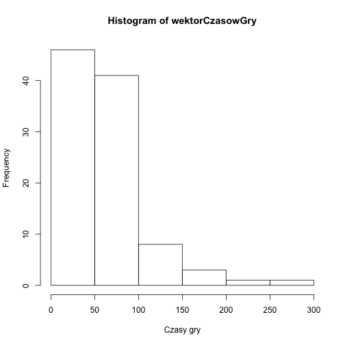

```r
SuperFarmerKapibary::badaj_gre(SuperFarmer.SuperDziewczyn::strategia_wymian_0_0_0_0,
                               powt=100,
                               progressBar=FALSE,
                               histogram=TRUE)
```

```
##    Min. 1st Qu.  Median    Mean 3rd Qu.    Max.
##   20.00   40.25   52.00   59.55   68.50  237.00
```

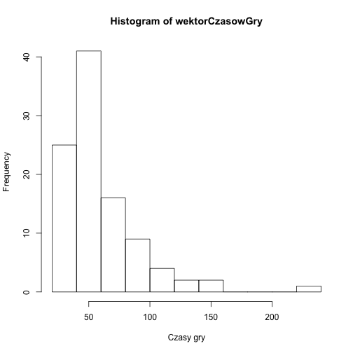

```r
SuperFarmerKapibary::badaj_gre(SuperFarmer.SuperDziewczyn::strategia_wymian_1_1_1_1,
                               powt=100,
                               progressBar=FALSE,
                               histogram=TRUE)
```

### SuperFarmerADiPR

```
##    Min. 1st Qu.  Median    Mean 3rd Qu.    Max.
##   11.00   27.00   37.00   42.04   53.25  108.00
```

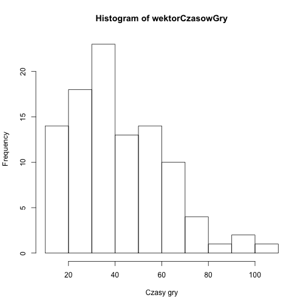

```r
SuperFarmerKapibary::badaj_gre(SuperFarmerADiPR::strategia_postMDiPR,
                               powt=100,
                               progressBar=FALSE,
                               histogram=TRUE)
```

```
##    Min. 1st Qu.  Median    Mean 3rd Qu.    Max.
##    24.0    56.0    75.0   101.6   130.2   336.0
```

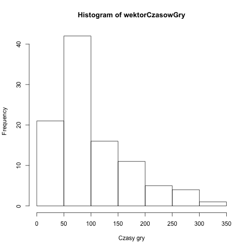

```r
SuperFarmerKapibary::badaj_gre(SuperFarmerADiPR::strategia_ADA,
                               powt=100,
                               progressBar=FALSE,
                               histogram=TRUE)
```

### SuperFarmerMoc

```
##    Min. 1st Qu.  Median    Mean 3rd Qu.    Max.
##   12.00   28.00   37.00   46.13   60.00  126.00
```

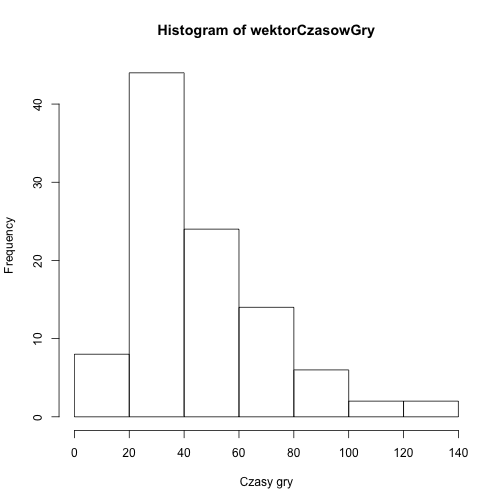

```r
SuperFarmerKapibary::badaj_gre(SuperFarmerMoc::strategia_postMDiPR,
                               powt=100,
                               progressBar=FALSE,
                               histogram=TRUE)
```

```
##    Min. 1st Qu.  Median    Mean 3rd Qu.    Max.
##   18.00   27.00   44.00   56.02   71.25  219.00
```

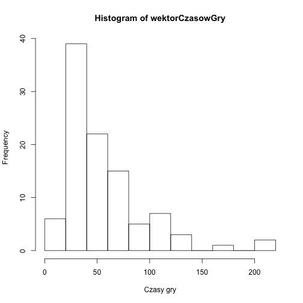

```r
SuperFarmerKapibary::badaj_gre(SuperFarmerMoc::strategia_Jana,
                               powt=100,
                               progressBar=FALSE,
                               histogram=TRUE)
```

# Testowanie strategii pierwszej na funkcji gra z czterech innych, wybranych pakietów

### SuperFarmerMoc

```r
SuperFarmerMoc:::gra(SuperFarmerKapibary::strategia_Pierwsza)
```

```
## [1] 81
```

### SuperFarmerADiPR

```r
SuperFarmerADiPR::gra(SuperFarmerKapibary::strategia_Pierwsza)
```

```
## [1] 197
```

### SuperFarmer.SuperDziewczyn

```r
SuperFarmer.SuperDziewczyn::gra(SuperFarmerKapibary::strategia_Pierwsza)
```

```
## [1] 139
```

### SuperFarmer.SuperPakiet

```r
SuperFarmer.SuperPakiet::gra(SuperFarmerKapibary::strategia_Pierwsza)
```

```
## [1] 35
```

# Testowanie strategii drugiej na funkcji gra z innych pakietów

### SuperFarmerMoc

```r
SuperFarmerMoc:::gra(SuperFarmerKapibary::strategia_Druga)
```

```
## [1] 44
```

### SuperFarmerADiPR

```r
SuperFarmerADiPR::gra(SuperFarmerKapibary::strategia_Druga)
```

```
## [1] 94
```

### SuperFarmer.SuperDziewczyn

```r
SuperFarmer.SuperDziewczyn::gra(SuperFarmerKapibary::strategia_Druga)
```

```
## [1] 25
```

### SuperFarmer.SuperPakiet

```r
SuperFarmer.SuperPakiet::gra(SuperFarmerKapibary::strategia_Druga)
```

```
## [1] 49
```